# CREW Survey 2025 - Complete Descriptive Analysis

Marco Pena

2025-06-25

# Introduction

# Data Setup and Preparation

```r
library(tidyverse)
library(janitor)
library(knitr)
library(kableExtra)
library(dplyr)
library(stringr)

crew_data <- readRDS("crew_dataset_keys_analysis_ready.rds")

# ====================================================================
# DATA CLEANING FUNCTIONS
# ====================================================================

clean_numeric_column <- function(x) {
  x_clean <- gsub("[^0-9.]", "", as.character(x))
  x_numeric <- suppressWarnings(as.numeric(ifelse(x_clean == "", NA, x_clean)))
  x_numeric[x_numeric > 99999999] <- NA
  return(x_numeric)
}

# Function to clean direct reports column
clean_direct_reports <- function(x) {
  x_clean <- case_when(
    str_detect(tolower(x), "everyone|varies") ~ NA_real_,
    str_detect(x, "^\\d+\\+?$") ~ as.numeric(str_extract(x, "\\d+")),
    str_detect(x, "^\\d+-\\d+$") ~ as.numeric(str_extract(x, "\\d+")),
    str_detect(tolower(x), "four") ~ 4,
    str_detect(tolower(x), "ten") ~ 10,
    TRUE ~ suppressWarnings(as.numeric(str_extract(x, "\\d+")))
  )
  x_clean[x_clean > 500] <- NA
  return(x_clean)
}

# ====================================================================
# APPLY DATA CLEANING
# ====================================================================

crew_data <- crew_data %>%
  mutate(
    # Clean gender variable
    gender_clean = case_when(
      str_to_lower(m27) %in% c("female", "woman") ~ "Women",
      str_to_lower(m27) %in% c("male", "man") ~ "Men",
      str_detect(str_to_lower(m27), "nonbinary|non-binary") ~ "Nonbinary",
      TRUE ~ NA_character_
    ),

    # Clean direct reports
    direct_reports_clean = clean_direct_reports(`G10Q78`),

    # Create simplified experience categories
    experience_simplified = case_when(
      m4A %in% c("Less than 1 year", "1-2 years", "3-5 years") ~ "5 or less",
      m4A %in% c("6-10 years") ~ "6-10",
      m4A %in% c("11-15 years", "16-20 years") ~ "11-20",
      m4A %in% c("More than 20 years", "21-25 years", "26-30 years", "More than 30 years") ~ "20+",
      TRUE ~ NA_character_
    ),

    # Create simplified education categories
    education_simplified = case_when(
      m28A %in% c("Graduated high school (grade 12)", "Some high school or less (grades 0-11)") ~ "High School",
      m28A == "Technical or trade school" ~ "Technical/Trade",
      m28A == "College/university" ~ "College Graduate",
      m28A == "Some post-graduate study" ~ "Some Post-Graduate",
      m28A == "Post-graduate degree" ~ "Post-Graduate Degree",
      TRUE ~ NA_character_
    ),

    # Create company size categories
    company_size_category = case_when(
      m8 %in% c("Just me (1)", "2-5", "6-10") ~ "Small (1-10)",
      m8 %in% c("11-25", "26-50") ~ "Medium (11-50)",
      m8 %in% c("51-100", "101-250") ~ "Large (51-250)",
      m8 %in% c("251-500", "More than 500") ~ "Very Large (250+)",
      TRUE ~ NA_character_
    ),

    # Clean work hours and create simplified work patterns
    office_hours_clean = pmin(clean_numeric_column(`HOURS[SQ001_SQ001]`), 80, na.rm = TRUE),
    remote_hours_clean = pmin(clean_numeric_column(`HOURS[SQ002_SQ001]`), 80, na.rm = TRUE),
    field_hours_clean = pmin(clean_numeric_column(`HOURS[SQ003_SQ001]`), 80, na.rm = TRUE)
  ) %>%
  mutate(
    total_work_hours = office_hours_clean + remote_hours_clean + field_hours_clean,
    work_arrangement = case_when(
      is.na(total_work_hours) | total_work_hours < 5 ~ "Unknown/Invalid",
      office_hours_clean / total_work_hours >= 0.7 ~ "Primarily Office",
      remote_hours_clean / total_work_hours >= 0.5 ~ "Primarily Remote",
      field_hours_clean / total_work_hours >= 0.4 ~ "Primarily Field",
      TRUE ~ "Mixed/Hybrid"
    )
  )

# Rename columns for survey participation
crew_data <- crew_data %>%
  rename(
    survey_2010 = 'i0[2]',
    survey_2015 = 'i0[3]',
    survey_2020 = 'i0[6]',
    survey_never = 'i0[4]',
    survey_unsure = 'i0[5]'
  )
```

# BASIC DEMOGRAPHICS & SAMPLE COMPOSITION (Plots 1-7)

## 1. Gender Distribution Across Years

This table shows the distribution of respondents by gender across different survey years from 2005 to 2025.

```r
# Current year (2025) data
gender_2025 <- crew_data %>%
  filter(!is.na(gender_clean)) %>%
  count(Gender = gender_clean) %>%
  mutate(Year = 2025)

# Historical data
historic <- tribble(
  ~Gender, ~`2005`, ~`2010`, ~`2015`, ~`2020`,
  "Women",    1175,    1972,    1700,    2414,
  "Men",       659,     929,     482,     512,
  "Nonbinary",   0,       0,       0,       4
)

# Combine historical and current data
gender_2025_wide <- gender_2025 %>%
  pivot_wider(names_from = Year, values_from = n) %>%
  rename(`2025` = `2025`)

gender_final <- historic %>%
  left_join(gender_2025_wide, by = "Gender") %>%
  mutate(Total = rowSums(across(where(is.numeric)), na.rm = TRUE))

# Add totals row
totals_row <- gender_final %>%
  summarise(across(where(is.numeric), sum)) %>%
  mutate(Gender = "Total") %>%
  select(Gender, everything())

gender_table_full <- bind_rows(gender_final, totals_row)

# Display table
gender_table_full %>%
  kable(caption = "Respondents: Gender and Year of Study", align = "c") %>%
  kable_styling(bootstrap_options = c("striped", "hover", "condensed", "responsive")) %>%
  row_spec(nrow(gender_table_full), bold = TRUE, background = "#e6f2f5") %>%
  column_spec(1, bold = TRUE)
```

Respondents: Gender and Year of Study

| Gender | 2005 | 2010 | 2015 | 2020 | 2025 | Total |
| --- | --- | --- | --- | --- | --- | --- |
| Women | 1175 | 1972 | 1700 | 2414 | 2078 | 9339 |
| Men | 659 | 929 | 482 | 512 | 349 | 2931 |
| Nonbinary | 0 | 0 | 0 | 4 | 10 | 14 |
| Total | 1834 | 2901 | 2182 | 2930 | 2437 | 12284 |

## 2. Geographic Distribution by Gender

This table presents the distribution of respondents by country and gender.

```r
# Create location table
location_table <- crew_data %>%
  filter(!is.na(gender_clean), !is.na(WHEREFROM)) %>%
  count(Country = WHEREFROM, Gender = gender_clean) %>%
  pivot_wider(names_from = Gender, values_from = n, values_fill = 0) %>%
  mutate(Total = rowSums(across(where(is.numeric))))

# Add total row
location_total <- location_table %>%
  summarise(across(where(is.numeric), sum)) %>%
  mutate(Country = "TOTAL") %>%
  select(Country, everything())

location_full <- bind_rows(location_table, location_total)

# Display table
location_full %>%
  kable(caption = "Respondents by Location and Gender", align = "c") %>%
  kable_styling(bootstrap_options = c("striped", "hover", "condensed")) %>%
  row_spec(nrow(location_full), bold = TRUE, background = "#e6f2f5") %>%
  column_spec(1, bold = TRUE)
```

Respondents by Location and Gender

| Country | Men | Nonbinary | Women | Total |
| --- | --- | --- | --- | --- |
| Argentina | 1 | 0 | 0 | 1 |
| Bahrain | 0 | 1 | 0 | 1 |
| Bangladesh | 1 | 0 | 0 | 1 |
| Brazil | 1 | 0 | 0 | 1 |
| Canada | 25 | 0 | 172 | 197 |
| Ghana | 1 | 0 | 0 | 1 |
| India | 1 | 0 | 0 | 1 |
| Mexico | 1 | 0 | 5 | 6 |
| Philippines | 0 | 0 | 1 | 1 |
| United Kingdom | 1 | 0 | 0 | 1 |
| United States | 314 | 9 | 1897 | 2220 |
| TOTAL | 346 | 10 | 2075 | 2431 |

## 3. Ethnicity/Race/Origin Distribution

This table shows the breakdown of respondents by ethnicity, race, or origin across gender categories.

```r
# Create ethnicity table
ethnicity_table <- crew_data %>%
  filter(!is.na(gender_clean), !is.na(G20Q70)) %>%
  count(Ethnicity = G20Q70, Gender = gender_clean) %>%
  pivot_wider(names_from = Gender, values_from = n, values_fill = 0) %>%
  mutate(Total = rowSums(across(where(is.numeric))))

# Add grand total row
ethnicity_total <- ethnicity_table %>%
  summarise(across(where(is.numeric), sum)) %>%
  mutate(Ethnicity = "Grand Total") %>%
  select(Ethnicity, everything())

ethnicity_full <- bind_rows(ethnicity_table, ethnicity_total)

# Display table
ethnicity_full %>%
  kable(caption = "Respondents: Ethnicity/Race/Origin", align = "c") %>%
  kable_styling(bootstrap_options = c("striped", "hover", "condensed")) %>%
  row_spec(nrow(ethnicity_full), bold = TRUE, background = "#e6f2f5") %>%
  column_spec(1, bold = TRUE)
```

Respondents: Ethnicity/Race/Origin

| Ethnicity | Men | Women | Nonbinary | Total |
| --- | --- | --- | --- | --- |
| African-American/Black | 11 | 52 | 0 | 63 |
| Asian | 12 | 49 | 0 | 61 |
| Hispanic/Latinx (Any Race) | 14 | 92 | 0 | 106 |
| Middle Eastern or North African | 0 | 6 | 0 | 6 |
| Native American or Alaskan | 1 | 5 | 0 | 6 |
| Other/mixed | 7 | 57 | 1 | 65 |
| Prefer not to answer | 10 | 21 | 2 | 33 |
| White (Non-Hispanic) | 243 | 1588 | 5 | 1836 |
| Grand Total | 298 | 1870 | 8 | 2176 |

## 4. Age Distribution by Gender

This chart shows the age distribution of respondents, comparing women and men across different age groups.

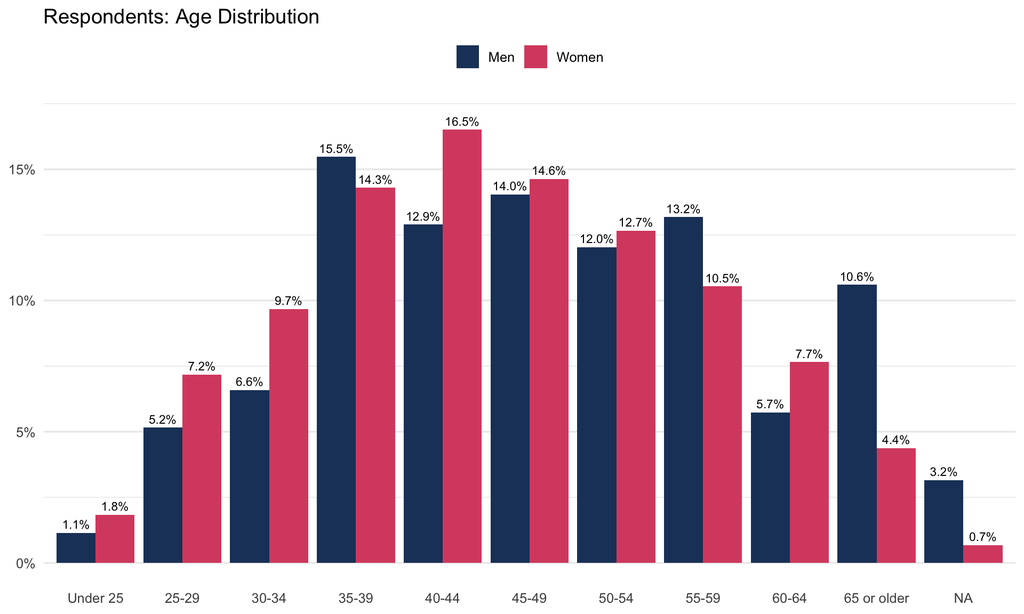

Age distribution of survey respondents by gender

```r
# Prepare age data
age_data <- crew_data %>%
  filter(gender_clean %in% c("Women", "Men"), !is.na(m25)) %>%
  count(Gender = gender_clean, AgeGroup = m25) %>%
  group_by(Gender) %>%
  mutate(Percent = n / sum(n) * 100)

# Standardize age group order
age_order <- c("Under 25", "25-29", "30-34", "35-39", "40-44", "45-49",
               "50-54", "55-59", "60-64", "65 or older")

age_data <- age_data %>%
  mutate(AgeGroup = factor(AgeGroup, levels = age_order))

# Create age distribution chart
ggplot(age_data, aes(x = AgeGroup, y = Percent, fill = Gender)) +
  geom_col(position = "dodge") +
  geom_text(aes(label = sprintf("%.1f%%", Percent)),
            position = position_dodge(width = 0.9), vjust = -0.5, size = 3) +
  scale_y_continuous(labels = scales::percent_format(scale = 1), limits = c(0, 17)) +
  scale_fill_manual(values = c("Women" = "#d94f70", "Men" = "#1f4068")) +
  labs(title = "Respondents: Age Distribution", x = NULL, y = NULL, fill = NULL) +
  theme_minimal(base_size = 12) +
  theme(legend.position = "top", axis.text.x = element_text(angle = 0, hjust = 0.5),
        panel.grid.major.x = element_blank())
```

## 5. Prior Survey Participation

This chart displays the participation history of respondents in previous benchmarking surveys.

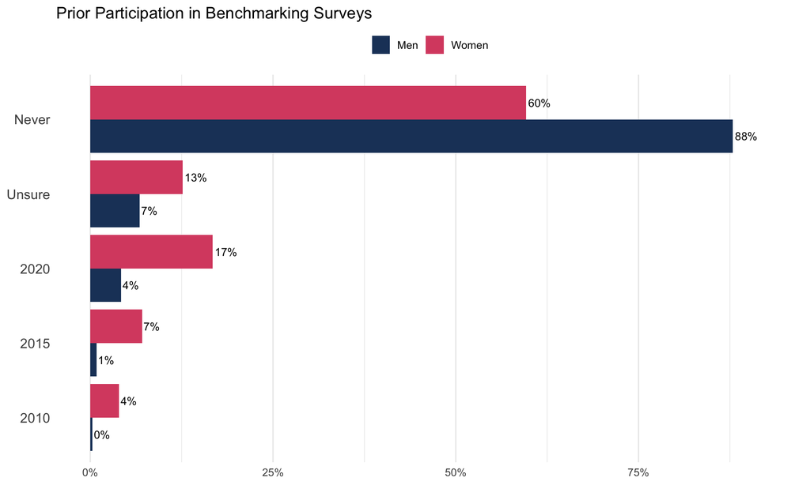

Prior participation in benchmarking surveys by gender

```r
# Prepare survey participation data
survey_long <- crew_data %>%
  filter(gender_clean %in% c("Women", "Men")) %>%
  pivot_longer(cols = c(survey_2010, survey_2015, survey_2020, survey_never, survey_unsure),
               names_to = "Survey_Year", values_to = "Response") %>%
  filter(Response == TRUE) %>%
  mutate(Survey_Year = case_when(
    Survey_Year == "survey_2010" ~ "2010",
    Survey_Year == "survey_2015" ~ "2015",
    Survey_Year == "survey_2020" ~ "2020",
    Survey_Year == "survey_never" ~ "Never",
    Survey_Year == "survey_unsure" ~ "Unsure"
  )) %>%
  count(Survey_Year, Gender = gender_clean) %>%
  group_by(Gender) %>%
  mutate(Percent = n / sum(n) * 100)

# Set order for visualization
survey_long <- survey_long %>%
  mutate(Survey_Year = factor(Survey_Year, levels = c("2010", "2015", "2020", "Unsure", "Never")))

# Create horizontal bar chart
ggplot(survey_long, aes(x = Percent, y = Survey_Year, fill = Gender)) +
  geom_col(position = "dodge") +
  geom_text(aes(label = sprintf("%.0f%%", Percent)),
            position = position_dodge(width = 0.9), hjust = -0.1, size = 3.5) +
  scale_fill_manual(values = c("Women" = "#d94f70", "Men" = "#1f4068")) +
  scale_x_continuous(labels = scales::percent_format(scale = 1),
                     limits = c(0, max(survey_long$Percent) + 5)) +
  labs(title = "Prior Participation in Benchmarking Surveys", x = NULL, y = NULL, fill = NULL) +
  theme_minimal(base_size = 12) +
  theme(legend.position = "top", axis.text.y = element_text(size = 12),
        panel.grid.major.y = element_blank())
```

## 6. Education Level Distribution

This chart shows the educational attainment of respondents by gender.

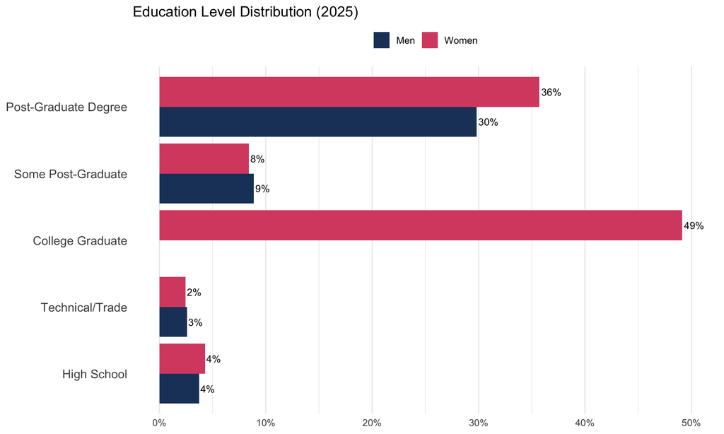

Educational attainment by gender

```r
# Prepare education data using simplified categories
edu_data <- crew_data %>%
  filter(gender_clean %in% c("Women", "Men"), !is.na(education_simplified)) %>%
  count(Education = education_simplified, Gender = gender_clean) %>%
  group_by(Gender) %>%
  mutate(Percent = n / sum(n) * 100) %>%
  ungroup()

# Set education level order
edu_levels <- c("High School", "Technical/Trade", "College Graduate",
                "Some Post-Graduate", "Post-Graduate Degree")

edu_data <- edu_data %>%
  mutate(Education = factor(Education, levels = edu_levels))

# Create horizontal bar chart
ggplot(edu_data, aes(x = Percent, y = Education, fill = Gender)) +
  geom_col(position = "dodge") +
  geom_text(aes(label = sprintf("%.0f%%", Percent)),
            position = position_dodge(width = 0.9), hjust = -0.1, size = 3.5) +
  scale_fill_manual(values = c("Women" = "#d94f70", "Men" = "#1f4068")) +
  scale_x_continuous(labels = scales::percent_format(scale = 1), limits = c(0, 50)) +
  labs(title = "Education Level Distribution (2025)", x = NULL, y = NULL, fill = NULL) +
  theme_minimal(base_size = 12) +
  theme(legend.position = "top", axis.text.y = element_text(size = 12),
        panel.grid.major.y = element_blank())
```

## 7. Years of Experience in CRE

This chart shows the distribution of years of experience in commercial real estate by gender.

[figure not shown]

Years of experience in commercial real estate by gender

```r
# Prepare experience data
exp_data <- crew_data %>%
  filter(gender_clean %in% c("Women", "Men"), !is.na(experience_simplified)) %>%
  count(Gender = gender_clean, Experience = experience_simplified) %>%
  group_by(Gender) %>%
  mutate(Percent = n / sum(n) * 100)

# Set proper order
exp_order <- c("5 or less", "6-10", "11-20", "20+")
exp_data <- exp_data %>%
  mutate(Experience = factor(Experience, levels = exp_order))

# Create chart
ggplot(exp_data, aes(x = Experience, y = Percent, fill = Gender)) +
  geom_col(position = "dodge") +
  geom_text(aes(label = sprintf("%.0f%%", Percent)),
            position = position_dodge(width = 0.9), vjust = -0.5, size = 3) +
  scale_fill_manual(values = c("Women" = "#d94f70", "Men" = "#1f4068")) +
  scale_y_continuous(labels = scales::percent_format(scale = 1)) +
  labs(title = "Years of Experience in CRE (2025)", x = "Years of Experience", y = NULL, fill = NULL) +
  theme_minimal() +
  theme(legend.position = "top")
```

# INDUSTRY & ROLE STRUCTURE (Plots 8-16)

## 8. Company Primary Industry Distribution

```r
industry_data <- crew_data %>%
  filter(!is.na(m1A), !is.na(gender_clean)) %>%
  count(Industry = m1A, Gender = gender_clean) %>%
  group_by(Industry) %>%
  mutate(Total = sum(n)) %>%
  ungroup() %>%
  filter(Total >= 10) %>%  # Only show industries with 10+ responses
  pivot_wider(names_from = Gender, values_from = n, values_fill = 0) %>%
  mutate(
    Total = Women + Men + ifelse("Nonbinary" %in% names(.), Nonbinary, 0),
    Percent_of_Sample = round((Total / sum(Total)) * 100, 1)
  ) %>%
  arrange(desc(Total))

# Create table
industry_data %>%
  select(Industry, Women, Men, Total, Percent_of_Sample) %>%
  kable(
    caption = "Company Primary Industry Distribution",
    col.names = c("Industry", "Women", "Men", "Total", "% of Sample"),
    align = "lcccc"
  ) %>%
  kable_styling(bootstrap_options = c("striped", "hover", "condensed"))
```

Company Primary Industry Distribution

| Industry | Women | Men | Total | % of Sample |
| --- | --- | --- | --- | --- |
| Architecture & Design Construction | 248 | 53 | 301 | 12.5 |
| Real Estate Brokerage | 235 | 62 | 297 | 12.3 |
| Real Estate Development | 241 | 30 | 271 | 11.2 |
| Other | 195 | 35 | 230 | 9.5 |
| Finance/Mortgages | 170 | 36 | 206 | 8.5 |
| Building/Contracting | 147 | 30 | 177 | 7.3 |
| Management: Property/Asset | 151 | 18 | 169 | 7.0 |
| Real Estate Consulting/Services | 133 | 22 | 155 | 6.4 |
| Engineering | 106 | 21 | 127 | 5.3 |
| Law | 119 | 8 | 127 | 5.3 |
| Investing/Corporate Real Estate | 99 | 7 | 106 | 4.4 |
| Multi-family | 53 | 2 | 55 | 2.3 |
| Not for Profit | 38 | 1 | 39 | 1.6 |
| Environmental | 29 | 6 | 35 | 1.4 |
| Appraisal | 22 | 7 | 29 | 1.2 |
| Public Sector | 24 | 3 | 27 | 1.1 |
| Economic Development | 17 | 2 | 19 | 0.8 |
| Manufacturing/Industrial | 16 | 1 | 17 | 0.7 |
| Not Real Estate Focused | 14 | 1 | 15 | 0.6 |
| Education | 11 | 2 | 13 | 0.5 |

## 9. Specialization Distribution

```r
# Create main specialization categories
crew_data_spec <- crew_data %>%
  filter(!is.na(gender_clean)) %>%
  mutate(
    main_category = case_when(
      m1B %in% c("Asset/Property Management", "Corporate Real Estate", "Portfolio Management") ~ "Asset_Property_Facilities",
      m1B %in% c("Brokerage/Sales/Leasing") ~ "Brokerage_Sales_Leasing",
      m1B %in% c("Acquisitions/ Dispositions", "Architecture and Design", "Construction",
                  "Development", "Economic Development", "Engineering", "Environmental",
                  "Interior Design", "Investments") ~ "Development_Services",
      m1B %in% c("Accounting", "Appraisal/Valuation", "Consulting", "Executive Management",
                  "Finance/Lending/Mortgage", "Human Resources", "Law",
                  "Marketing/Business Development", "Sustainability", "Title/Escrow") ~ "Financial_Professional",
      TRUE ~ "Other"
    )
  ) %>%
  filter(!is.na(main_category))

# Calculate summary statistics for main categories
main_category_stats <- crew_data_spec %>%
  count(main_category, gender_clean) %>%
  pivot_wider(names_from = gender_clean, values_from = n, values_fill = 0) %>%
  mutate(
    Total = Women + Men + ifelse("Nonbinary" %in% names(.), Nonbinary, 0),
    Women_Percent = round((Women / Total) * 100, 1),
    Men_Percent = round((Men / Total) * 100, 1)
  ) %>%
  arrange(desc(Total))

# Create formatted table for display
specialization_summary <- main_category_stats %>%
  mutate(
    Category = case_when(
      main_category == "Asset_Property_Facilities" ~ "Asset • Property • Facilities Management",
      main_category == "Brokerage_Sales_Leasing" ~ "Brokerage • Sales • Leasing",
      main_category == "Development_Services" ~ "Development • Development Services",
      main_category == "Financial_Professional" ~ "Financial • Professional Services",
      main_category == "Other" ~ "Other",
      TRUE ~ main_category
    ),
    Women_Percent_Display = paste0(Women_Percent, "%"),
    Men_Percent_Display = paste0(Men_Percent, "%")
  ) %>%
  select(Category, Women, Women_Percent_Display, Men, Men_Percent_Display, Total) %>%
  arrange(desc(Total))

# Display table
specialization_summary %>%
  kable(
    caption = "Specialization by Respondents",
    col.names = c("Specialization Category", "Women", "% Women", "Men", "% Men", "Total"),
    align = "lccccc"
  ) %>%
  kable_styling(
    bootstrap_options = c("striped", "hover", "condensed", "responsive"),
    full_width = FALSE
  ) %>%
  column_spec(1, bold = TRUE, width = "4cm") %>%
  row_spec(0, bold = TRUE, background = "#f8f9fa")
```

Specialization by Respondents

| Specialization Category | Women | % Women | Men | % Men | Total |
| --- | --- | --- | --- | --- | --- |
| Financial • Professional Services | 859 | 88% | 116 | 11.9% | 976 |
| Development • Development Services | 627 | 83.2% | 126 | 16.7% | 754 |
| Asset • Property • Facilities Management | 332 | 90.5% | 34 | 9.3% | 367 |
| Brokerage • Sales • Leasing | 170 | 77.3% | 49 | 22.3% | 220 |
| Other | 90 | 78.3% | 24 | 20.9% | 115 |

## 10. Asset Class Distribution

```r
# Calculate comprehensive asset class statistics
calculate_asset_stats <- function(column_name) {
  total_count <- sum(crew_data[[column_name]] == TRUE, na.rm = TRUE)
  asset_respondents <- crew_data %>% filter(!!sym(column_name) == TRUE)

  women_count <- sum(asset_respondents$gender_clean == "Women", na.rm = TRUE)
  men_count <- sum(asset_respondents$gender_clean == "Men", na.rm = TRUE)

  women_pct <- if(total_count > 0) round((women_count / total_count) * 100, 1) else 0
  men_pct <- if(total_count > 0) round((men_count / total_count) * 100, 1) else 0

  return(list(
    total_count = total_count,
    women_count = women_count,
    men_count = men_count,
    women_pct = women_pct,
    men_pct = men_pct
  ))
}

# Calculate for all asset classes
office_stats <- calculate_asset_stats("m2B[SQ001]")
multifamily_stats <- calculate_asset_stats("m2B[SQ004]")
retail_stats <- calculate_asset_stats("m2B[SQ003]")
industrial_stats <- calculate_asset_stats("m2B[SQ002]")
mixed_stats <- calculate_asset_stats("m2B[SQ006]")
healthcare_stats <- calculate_asset_stats("m2B[SQ007]")
hotel_stats <- calculate_asset_stats("m2B[SQ005]")
education_stats <- calculate_asset_stats("m2B[SQ008]")
public_stats <- calculate_asset_stats("m2B[SQ009]")

# Create comprehensive summary table
asset_detailed <- data.frame(
  Asset_Class = c("Office", "Multifamily", "Retail", "Industrial/Manufacturing",
                  "Mixed-Use", "Healthcare", "Hotel/Motel", "Education", "Public Sector"),
  Total_Respondents = c(office_stats$total_count, multifamily_stats$total_count,
                       retail_stats$total_count, industrial_stats$total_count,
                       mixed_stats$total_count, healthcare_stats$total_count,
                       hotel_stats$total_count, education_stats$total_count,
                       public_stats$total_count),
  Women_Count = c(office_stats$women_count, multifamily_stats$women_count,
                 retail_stats$women_count, industrial_stats$women_count,
                 mixed_stats$women_count, healthcare_stats$women_count,
                 hotel_stats$women_count, education_stats$women_count,
                 public_stats$women_count),
  Women_Percent = c(office_stats$women_pct, multifamily_stats$women_pct,
                   retail_stats$women_pct, industrial_stats$women_pct,
                   mixed_stats$women_pct, healthcare_stats$women_pct,
                   hotel_stats$women_pct, education_stats$women_pct,
                   public_stats$women_pct),
  Men_Count = c(office_stats$men_count, multifamily_stats$men_count,
               retail_stats$men_count, industrial_stats$men_count,
               mixed_stats$men_count, healthcare_stats$men_count,
               hotel_stats$men_count, education_stats$men_count,
               public_stats$men_count),
  Men_Percent = c(office_stats$men_pct, multifamily_stats$men_pct,
                 retail_stats$men_pct, industrial_stats$men_pct,
                 mixed_stats$men_pct, healthcare_stats$men_pct,
                 hotel_stats$men_pct, education_stats$men_pct,
                 public_stats$men_pct)
) %>%
  arrange(desc(Total_Respondents)) %>%
  mutate(
    Women_Percent = paste0(Women_Percent, "%"),
    Men_Percent = paste0(Men_Percent, "%")
  )

# Display table
asset_detailed %>%
  kable(
    caption = "Respondents: Asset Class Distribution with Gender Breakdown",
    col.names = c("Asset Class", "Total", "Women", "% Women", "Men", "% Men"),
    align = "lcccccc"
  ) %>%
  kable_styling(
    bootstrap_options = c("striped", "hover", "condensed", "responsive"),
    full_width = TRUE
  ) %>%
  column_spec(1, bold = TRUE) %>%
  add_header_above(c(" " = 2, "Women" = 2, "Men" = 2)) %>%
  add_footnote("Note: Respondents could indicate more than one asset class", notation = "none")
```

Respondents: Asset Class Distribution with Gender Breakdown

| Asset Class | Total | Women | Women % Women | Men | Men % Men |
| --- | --- | --- | --- | --- | --- |
| Office | 2028 | 1132 | 55.8% | 218 | 10.7% |
| Multifamily | 1776 | 1013 | 57% | 172 | 9.7% |
| Retail | 1665 | 922 | 55.4% | 175 | 10.5% |
| Industrial/Manufacturing | 1595 | 899 | 56.4% | 178 | 11.2% |
| Mixed-Use | 1420 | 810 | 57% | 156 | 11% |
| Healthcare | 893 | 492 | 55.1% | 104 | 11.6% |
| Hotel/Motel | 802 | 443 | 55.2% | 109 | 13.6% |
| Education | 613 | 346 | 56.4% | 76 | 12.4% |
| Public Sector | 535 | 299 | 55.9% | 52 | 9.7% |

Note: Respondents could indicate more than one asset class

## 11. Current Position Levels

```r
position_data <- crew_data %>%
  filter(!is.na(m3A), !is.na(gender_clean)) %>%
  count(Position = m3A, Gender = gender_clean) %>%
  pivot_wider(names_from = Gender, values_from = n, values_fill = 0) %>%
  mutate(
    Total = Women + Men + ifelse("Nonbinary" %in% names(.), Nonbinary, 0),
    Women_Pct = round((Women / Total) * 100, 1),
    Men_Pct = round((Men / Total) * 100, 1)
  ) %>%
  arrange(desc(Total))

position_data %>%
  select(Position, Women, Men, Total, Women_Pct, Men_Pct) %>%
  kable(
    caption = "Current Position Distribution",
    col.names = c("Position Level", "Women", "Men", "Total", "% Women", "% Men"),
    align = "lccccc"
  ) %>%
  kable_styling(bootstrap_options = c("striped", "hover", "condensed"))
```

Current Position Distribution

| Position Level | Women | Men | Total | % Women | % Men |
| --- | --- | --- | --- | --- | --- |
| Senior level - experienced professional, you report directly to the vice president (or equivalent level) and higher | 679 | 111 | 790 | 85.9 | 14.1 |
| SVP/Vice President/Managing Director/Partner | 517 | 97 | 614 | 84.2 | 15.8 |
| Mid-level/Associate - multiple years of experience, may lead small teams, increasing responsibility | 481 | 71 | 552 | 87.1 | 12.9 |
| C-Suite - President/CEO/CFO/COO | 187 | 33 | 220 | 85.0 | 15.0 |
| Self-employed/Independent contractor | 102 | 21 | 123 | 82.9 | 17.1 |
| Entry level - limited experience, no direct reports | 90 | 14 | 104 | 86.5 | 13.5 |
| Unemployed | 14 | 1 | 15 | 93.3 | 6.7 |
| Retired | 8 | 1 | 9 | 88.9 | 11.1 |

## 12. Employment Status

```r
employment_summary <- crew_data %>%
  filter(!is.na(i2)) %>%
  count(Employment_Status = i2) %>%
  mutate(Percent = round((n / sum(n)) * 100, 1)) %>%
  arrange(desc(n))

employment_summary %>%
  kable(caption = "Current Employment Status", align = "lcc") %>%
  kable_styling(bootstrap_options = c("striped", "hover", "condensed"))
```

Current Employment Status

| Employment_Status | n | Percent |
| --- | --- | --- |
| TRUE | 3680 | 98.2 |
| FALSE | 66 | 1.8 |

## 13. Company Size by Employees

[figure not shown]

Company size by number of employees

```r
company_size_data <- crew_data %>%
  filter(!is.na(company_size_category)) %>%
  count(Size = company_size_category) %>%
  mutate(Percent = round((n / sum(n)) * 100, 1)) %>%
  arrange(desc(n))

ggplot(company_size_data, aes(x = reorder(Size, n), y = n)) +
  geom_col(fill = "#34495e") +
  geom_text(aes(label = paste0(n, " (", Percent, "%)")),
            hjust = -0.1, size = 3.5) +
  coord_flip() +
  labs(title = "Company Size Distribution (2025)", x = "Company Size", y = "Number of Respondents") +
  theme_minimal()
```

## 14. Company Revenue Distribution

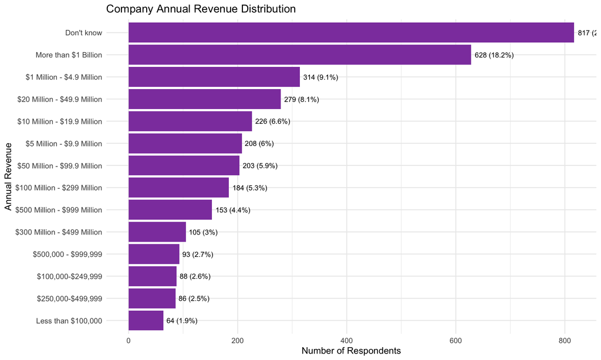

Company annual revenue distribution

```r
revenue_data <- crew_data %>%
  filter(!is.na(m29)) %>%
  count(Revenue = m29) %>%
  mutate(Percent = round((n / sum(n)) * 100, 1)) %>%
  arrange(desc(n))

ggplot(revenue_data, aes(x = reorder(Revenue, n), y = n)) +
  geom_col(fill = "#8e44ad") +
  geom_text(aes(label = paste0(n, " (", Percent, "%)")),
            hjust = -0.1, size = 3) +
  coord_flip() +
  labs(title = "Company Annual Revenue Distribution", x = "Annual Revenue", y = "Number of Respondents") +
  theme_minimal() +
  theme(axis.text.y = element_text(size = 9))
```

## 15. Company Type Distribution

```r
company_type_data <- crew_data %>%
  filter(!is.na(m30A)) %>%
  count(Company_Type = m30A) %>%
  mutate(Percent = round((n / sum(n)) * 100, 1)) %>%
  arrange(desc(n))

company_type_data %>%
  kable(
    caption = "Company Type Distribution",
    col.names = c("Company Type", "Count", "Percentage"),
    align = "lcc"
  ) %>%
  kable_styling(bootstrap_options = c("striped", "hover", "condensed"))
```

Company Type Distribution

| Company Type | Count | Percentage |
| --- | --- | --- |
| Regional (across several nearby markets) | 1111 | 32.2 |
| National | 1013 | 29.4 |
| International | 962 | 27.9 |
| Local (across a single market) | 364 | 10.6 |

## 16. Ownership Structure

```r
ownership_data <- crew_data %>%
  filter(!is.na(m30B)) %>%
  count(Ownership = m30B) %>%
  mutate(Percent = round((n / sum(n)) * 100, 1)) %>%
  arrange(desc(n))

ownership_data %>%
  kable(
    caption = "Company Ownership Structure",
    col.names = c("Ownership Structure", "Count", "Percentage"),
    align = "lcc"
  ) %>%
  kable_styling(bootstrap_options = c("striped", "hover", "condensed"))
```

Company Ownership Structure

| Ownership Structure | Count | Percentage |
| --- | --- | --- |
| Privately held corporation | 1328 | 38.5 |
| Publicly held corporation | 671 | 19.5 |
| Partnership | 557 | 16.2 |
| Small Business | 332 | 9.6 |
| Other | 183 | 5.3 |
| Sole proprietorship | 155 | 4.5 |
| Non profit | 137 | 4.0 |
| Publicly held REIT | 85 | 2.5 |

# WORKFORCE COMPOSITION (Plots 17-21)

## 17. CRE Professionals at Location

```r
cre_prof_data <- crew_data %>%
  filter(!is.na(m9A)) %>%
  mutate(
    cre_size = case_when(
      m9A %in% c("1", "2-5") ~ "Small (1-5)",
      m9A %in% c("6-10", "11-25") ~ "Medium (6-25)",
      m9A %in% c("26-50", "51-100") ~ "Large (26-100)",
      m9A %in% c("More than 100") ~ "Very Large (100+)",
      TRUE ~ "Other"
    )
  ) %>%
  filter(cre_size != "Other") %>%
  count(cre_size) %>%
  mutate(Percent = round((n / sum(n)) * 100, 1))

cre_prof_data %>%
  kable(
    caption = "Number of CRE Professionals at Location",
    col.names = c("CRE Team Size", "Count", "Percentage"),
    align = "lcc"
  ) %>%
  kable_styling(bootstrap_options = c("striped", "hover", "condensed"))
```

Number of CRE Professionals at Location

| CRE Team Size | Count | Percentage |
| --- | --- | --- |
| Small (1-5) | 251 | 100 |

## 18. Gender Distribution at Workplace (Estimated by Respondents)

```r
workplace_gender <- crew_data %>%
  filter(!is.na(`m9C[SQ002]`)) %>%  # Female percentage
  mutate(
    female_range = case_when(
      `m9C[SQ002]` >= 0 & `m9C[SQ002]` < 25 ~ "< 25% women",
      `m9C[SQ002]` >= 25 & `m9C[SQ002]` < 50 ~ "25-49% women",
      `m9C[SQ002]` >= 50 & `m9C[SQ002]` < 75 ~ "50-74% women",
      `m9C[SQ002]` >= 75 ~ "75%+ women",
      TRUE ~ "Unknown"
    )
  ) %>%
  count(female_range) %>%
  mutate(Percent = round((n / sum(n)) * 100, 1))

workplace_gender %>%
  kable(
    caption = "Workplace Gender Distribution (as estimated by respondents)",
    col.names = c("Women Representation", "Count", "Percentage"),
    align = "lcc"
  ) %>%
  kable_styling(bootstrap_options = c("striped", "hover", "condensed"))
```

Workplace Gender Distribution (as estimated by respondents)

| Women Representation | Count | Percentage |
| --- | --- | --- |
| 25-49% women | 710 | 53.5 |
| 50-74% women | 338 | 25.5 |
| 75%+ women | 28 | 2.1 |
| < 25% women | 250 | 18.9 |

## 19. Specialization Team Size

```r
spec_team_data <- crew_data %>%
  filter(!is.na(m9E)) %>%
  mutate(
    team_size = case_when(
      as.numeric(m9E) <= 5 ~ "Small (1-5)",
      as.numeric(m9E) %in% 6:15 ~ "Medium (6-15)",
      as.numeric(m9E) %in% 16:50 ~ "Large (16-50)",
      as.numeric(m9E) > 50 ~ "Very Large (50+)",
      TRUE ~ "Unknown"
    )
  ) %>%
  filter(team_size != "Unknown") %>%
  count(team_size) %>%
  mutate(Percent = round((n / sum(n)) * 100, 1))

spec_team_data %>%
  kable(
    caption = "Specialization Team Size Distribution",
    col.names = c("Team Size", "Count", "Percentage"),
    align = "lcc"
  ) %>%
  kable_styling(bootstrap_options = c("striped", "hover", "condensed"))
```

Specialization Team Size Distribution

| Team Size | Count | Percentage |
| --- | --- | --- |
| Large (16-50) | 453 | 14.2 |
| Medium (6-15) | 718 | 22.5 |
| Small (1-5) | 1838 | 57.6 |
| Very Large (50+) | 182 | 5.7 |

## 20. Senior Roles Count

```r
senior_roles_data <- crew_data %>%
  filter(!is.na(m10A)) %>%
  mutate(
    senior_roles = case_when(
      as.numeric(m10A) == 0 ~ "None",
      as.numeric(m10A) %in% 1:3 ~ "1-3 roles",
      as.numeric(m10A) %in% 4:10 ~ "4-10 roles",
      as.numeric(m10A) > 10 ~ "10+ roles",
      TRUE ~ "Unknown"
    )
  ) %>%
  filter(senior_roles != "Unknown") %>%
  count(senior_roles) %>%
  mutate(Percent = round((n / sum(n)) * 100, 1))

senior_roles_data %>%
  kable(
    caption = "Senior Level Roles in Specialization",
    col.names = c("Senior Roles", "Count", "Percentage"),
    align = "lcc"
  ) %>%
  kable_styling(bootstrap_options = c("striped", "hover", "condensed"))
```

Senior Level Roles in Specialization

| Senior Roles | Count | Percentage |
| --- | --- | --- |
| 1-3 roles | 1556 | 50.2 |
| 10+ roles | 446 | 14.4 |
| 4-10 roles | 911 | 29.4 |
| None | 189 | 6.1 |

## 21. Gender Distribution in Senior Roles

```r
senior_gender <- crew_data %>%
  filter(!is.na(`m10C[SQ002]`)) %>%  # Female percentage in senior roles
  mutate(
    female_senior_range = case_when(
      `m10C[SQ002]` == 0 ~ "0% women",
      `m10C[SQ002]` > 0 & `m10C[SQ002]` < 25 ~ "1-24% women",
      `m10C[SQ002]` >= 25 & `m10C[SQ002]` < 50 ~ "25-49% women",
      `m10C[SQ002]` >= 50 & `m10C[SQ002]` < 75 ~ "50-74% women",
      `m10C[SQ002]` >= 75 ~ "75%+ women",
      TRUE ~ "Unknown"
    )
  ) %>%
  count(female_senior_range) %>%
  mutate(Percent = round((n / sum(n)) * 100, 1))

senior_gender %>%
  kable(
    caption = "Gender Distribution in Senior Roles (as estimated by respondents)",
    col.names = c("Women in Senior Roles", "Count", "Percentage"),
    align = "lcc"
  ) %>%
  kable_styling(bootstrap_options = c("striped", "hover", "condensed"))
```

Gender Distribution in Senior Roles (as estimated by respondents)

| Women in Senior Roles | Count | Percentage |
| --- | --- | --- |
| 1-24% women | 61 | 41.8 |
| 25-49% women | 61 | 41.8 |
| 50-74% women | 24 | 16.4 |

# MANAGEMENT STRUCTURE (Plots 22-25)

## 22. Direct Reports (Yes/No)

```r
direct_reports <- crew_data %>%
  filter(!is.na(m11A)) %>%
  count(Has_Reports = m11A) %>%
  mutate(Percent = round((n / sum(n)) * 100, 1))

direct_reports %>%
  kable(
    caption = "Professionals with Direct Reports",
    col.names = c("Has Direct Reports", "Count", "Percentage"),
    align = "lcc"
  ) %>%
  kable_styling(bootstrap_options = c("striped", "hover", "condensed"))
```

Professionals with Direct Reports

| Has Direct Reports | Count | Percentage |
| --- | --- | --- |
| FALSE | 1464 | 48.3 |
| TRUE | 1569 | 51.7 |

## 23. Number of Direct Reports

```r
num_reports <- crew_data %>%
  filter(m11A == TRUE, !is.na(direct_reports_clean)) %>%
  mutate(
    report_range = case_when(
      direct_reports_clean == 1 ~ "1 person",
      direct_reports_clean %in% 2:5 ~ "2-5 people",
      direct_reports_clean %in% 6:10 ~ "6-10 people",
      direct_reports_clean %in% 11:20 ~ "11-20 people",
      direct_reports_clean > 20 ~ "20+ people",
      TRUE ~ "Unknown"
    )
  ) %>%
  count(report_range) %>%
  mutate(Percent = round((n / sum(n)) * 100, 1))

num_reports %>%
  kable(
    caption = "Number of Direct Reports (among managers)",
    col.names = c("Number of Reports", "Count", "Percentage"),
    align = "lcc"
  ) %>%
  kable_styling(bootstrap_options = c("striped", "hover", "condensed"))
```

Number of Direct Reports (among managers)

| Number of Reports | Count | Percentage |
| --- | --- | --- |
| 1 person | 317 | 20.5 |
| 11-20 people | 117 | 7.5 |
| 2-5 people | 766 | 49.4 |
| 20+ people | 82 | 5.3 |
| 6-10 people | 266 | 17.2 |
| Unknown | 2 | 0.1 |

## 24. Gender Distribution of Direct Reports

```r
reports_gender <- crew_data %>%
  filter(!is.na(`m11B[SQ002]`)) %>%  # Female percentage of direct reports
  mutate(
    female_reports_range = case_when(
      `m11B[SQ002]` == 0 ~ "0% women",
      `m11B[SQ002]` > 0 & `m11B[SQ002]` < 25 ~ "1-24% women",
      `m11B[SQ002]` >= 25 & `m11B[SQ002]` < 50 ~ "25-49% women",
      `m11B[SQ002]` >= 50 & `m11B[SQ002]` < 75 ~ "50-74% women",
      `m11B[SQ002]` >= 75 ~ "75%+ women",
      TRUE ~ "Unknown"
    )
  ) %>%
  count(female_reports_range) %>%
  mutate(Percent = round((n / sum(n)) * 100, 1))

reports_gender %>%
  kable(
    caption = "Gender Distribution of Direct Reports (as estimated by managers)",
    col.names = c("Women Among Reports", "Count", "Percentage"),
    align = "lcc"
  ) %>%
  kable_styling(bootstrap_options = c("striped", "hover", "condensed"))
```

Gender Distribution of Direct Reports (as estimated by managers)

| Women Among Reports | Count | Percentage |
| --- | --- | --- |
| 1-24% women | 13 | 22.4 |
| 25-49% women | 25 | 43.1 |
| 50-74% women | 15 | 25.9 |
| 75%+ women | 5 | 8.6 |

## 25. Management Experience

```r
# Promotions and career moves
mgmt_moves <- crew_data %>%
  filter(!is.na(`m12A[SQ001]`)) %>%  # Accepted promotions
  mutate(
    promotions = case_when(
      as.numeric(`m12A[SQ001]`) == 0 ~ "No promotions",
      as.numeric(`m12A[SQ001]`) %in% 1:2 ~ "1-2 promotions",
      as.numeric(`m12A[SQ001]`) %in% 3:5 ~ "3-5 promotions",
      as.numeric(`m12A[SQ001]`) > 5 ~ "5+ promotions",
      TRUE ~ "Unknown"
    )
  ) %>%
  filter(promotions != "Unknown") %>%
  count(promotions) %>%
  mutate(Percent = round((n / sum(n)) * 100, 1))

mgmt_moves %>%
  kable(
    caption = "Number of Promotions Accepted in CRE Career",
    col.names = c("Promotions", "Count", "Percentage"),
    align = "lcc"
  ) %>%
  kable_styling(bootstrap_options = c("striped", "hover", "condensed"))
```

Number of Promotions Accepted in CRE Career

| Promotions | Count | Percentage |
| --- | --- | --- |
| 1-2 promotions | 1170 | 39.5 |
| 3-5 promotions | 1115 | 37.6 |
| 5+ promotions | 235 | 7.9 |
| No promotions | 444 | 15.0 |

# WORK PATTERNS & ARRANGEMENTS (Plots 26-27)

## 26. Work Arrangement Patterns

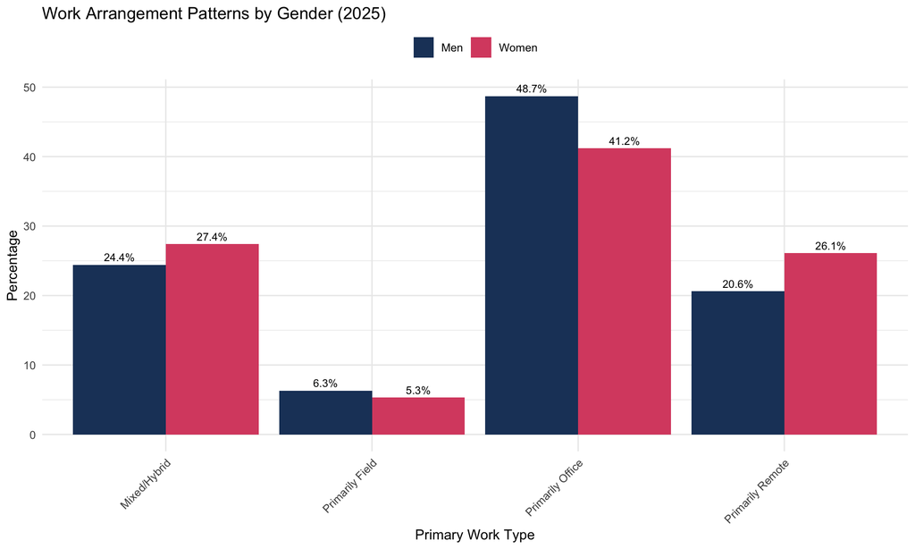

Work arrangement patterns by gender

```r
work_data <- crew_data %>%
  filter(!is.na(work_arrangement), work_arrangement != "Unknown/Invalid",
         gender_clean %in% c("Women", "Men")) %>%
  count(Work_Type = work_arrangement, Gender = gender_clean) %>%
  group_by(Gender) %>%
  mutate(Percent = round((n / sum(n)) * 100, 1))

ggplot(work_data, aes(x = Work_Type, y = Percent, fill = Gender)) +
  geom_col(position = "dodge") +
  geom_text(aes(label = paste0(Percent, "%")),
            position = position_dodge(width = 0.9), vjust = -0.5, size = 3) +
  scale_fill_manual(values = c("Women" = "#d94f70", "Men" = "#1f4068")) +
  labs(
    title = "Work Arrangement Patterns by Gender (2025)",
    x = "Primary Work Type",
    y = "Percentage",
    fill = NULL
  ) +
  theme_minimal() +
  theme(
    legend.position = "top",
    axis.text.x = element_text(angle = 45, hjust = 1)
  )
```

```r
# Summary table
work_summary <- crew_data %>%
  filter(!is.na(work_arrangement), work_arrangement != "Unknown/Invalid") %>%
  count(work_arrangement) %>%
  mutate(Percent = round((n / sum(n)) * 100, 1)) %>%
  arrange(desc(n))

work_summary %>%
  kable(
    caption = "Work Arrangement Distribution (2025)",
    col.names = c("Work Arrangement", "Count", "Percentage"),
    align = "lcc"
  ) %>%
  kable_styling(bootstrap_options = c("striped", "hover", "condensed"))
```

Work Arrangement Distribution (2025)

| Work Arrangement | Count | Percentage |
| --- | --- | --- |
| Mixed/Hybrid | 2408 | 57.5 |
| Primarily Office | 1028 | 24.6 |
| Primarily Remote | 619 | 14.8 |
| Primarily Field | 132 | 3.2 |

## 27. Work Hours Distribution

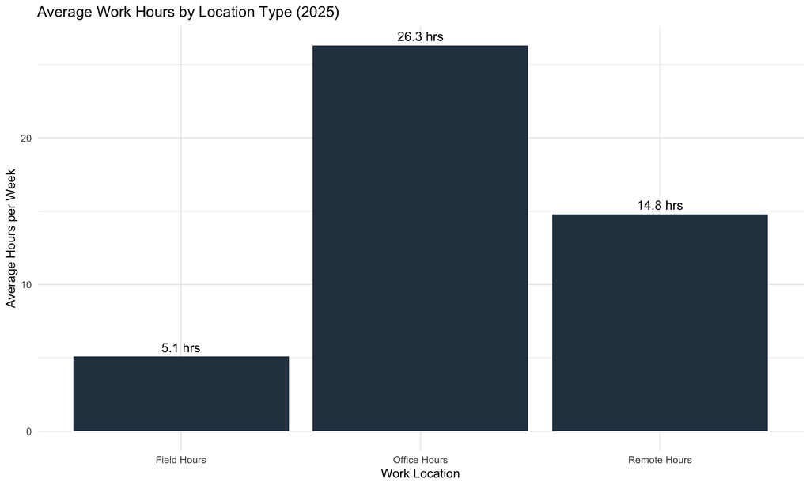

Distribution of work hours by type

```r
# Calculate average hours by work type
hours_summary <- crew_data %>%
  filter(!is.na(office_hours_clean), !is.na(remote_hours_clean), !is.na(field_hours_clean),
         total_work_hours >= 5, total_work_hours <= 80) %>%
  summarise(
    Office_Hours = round(mean(office_hours_clean, na.rm = TRUE), 1),
    Remote_Hours = round(mean(remote_hours_clean, na.rm = TRUE), 1),
    Field_Hours = round(mean(field_hours_clean, na.rm = TRUE), 1),
    Total_Sample = n()
  ) %>%
  pivot_longer(cols = c("Office_Hours", "Remote_Hours", "Field_Hours"),
               names_to = "Work_Type", values_to = "Average_Hours") %>%
  mutate(Work_Type = str_replace(Work_Type, "_", " "))

ggplot(hours_summary, aes(x = Work_Type, y = Average_Hours)) +
  geom_col(fill = "#2c3e50") +
  geom_text(aes(label = paste0(Average_Hours, " hrs")), vjust = -0.5, size = 4) +
  labs(
    title = "Average Work Hours by Location Type (2025)",
    x = "Work Location",
    y = "Average Hours per Week"
  ) +
  theme_minimal()
```

```r
# Detailed breakdown table - simplified to avoid pivot issues
hours_table <- crew_data %>%
  filter(!is.na(office_hours_clean), !is.na(remote_hours_clean), !is.na(field_hours_clean),
         total_work_hours >= 5, total_work_hours <= 80) %>%
  summarise(
    `Work Type` = c("Office", "Remote", "Field"),
    `Mean Hours` = c(
      round(mean(office_hours_clean, na.rm = TRUE), 1),
      round(mean(remote_hours_clean, na.rm = TRUE), 1),
      round(mean(field_hours_clean, na.rm = TRUE), 1)
    ),
    `Median Hours` = c(
      round(median(office_hours_clean, na.rm = TRUE), 1),
      round(median(remote_hours_clean, na.rm = TRUE), 1),
      round(median(field_hours_clean, na.rm = TRUE), 1)
    )
  )

# Create the table manually to avoid pivot issues
data.frame(
  Work_Type = c("Office", "Remote", "Field"),
  Mean_Hours = c(
    round(mean(crew_data$office_hours_clean, na.rm = TRUE), 1),
    round(mean(crew_data$remote_hours_clean, na.rm = TRUE), 1),
    round(mean(crew_data$field_hours_clean, na.rm = TRUE), 1)
  ),
  Median_Hours = c(
    round(median(crew_data$office_hours_clean, na.rm = TRUE), 1),
    round(median(crew_data$remote_hours_clean, na.rm = TRUE), 1),
    round(median(crew_data$field_hours_clean, na.rm = TRUE), 1)
  )
) %>%
  kable(
    caption = "Work Hours Summary Statistics (2025)",
    col.names = c("Work Type", "Mean Hours", "Median Hours"),
    align = "lcc"
  ) %>%
  kable_styling(bootstrap_options = c("striped", "hover", "condensed"))
```

Work Hours Summary Statistics (2025)

| Work Type | Mean Hours | Median Hours |
| --- | --- | --- |
| Office | 49.1 | 44 |
| Remote | 42.4 | 32 |
| Field | 36.9 | 10 |

# DATA QUALITY SUMMARY

```r
cat("📊 DATA QUALITY SUMMARY FOR DESCRIPTIVE PLOTS\n")
```

```
## 📊 DATA QUALITY SUMMARY FOR DESCRIPTIVE PLOTS
```

```r
cat("============================================\n\n")
# Response rates for key variables
quality_check <- crew_data %>%
  summarise(
    total_responses = n(),
    gender_available = sum(!is.na(gender_clean)),
    age_available = sum(!is.na(m25)),
    location_available = sum(!is.na(WHEREFROM)),
    education_available = sum(!is.na(education_simplified)),
    experience_available = sum(!is.na(experience_simplified)),
    work_arrangement_valid = sum(!is.na(work_arrangement) & work_arrangement != "Unknown/Invalid"),
    specialization_available = sum(!is.na(m1B)),
    position_available = sum(!is.na(m3A)),
    .groups = 'drop'
  )

cat("Response Rates:\n")
```

```
## Response Rates:
```

```r
cat("Total respondents:", quality_check$total_responses, "\n")
```

```
## Total respondents: 4191
```

```r
cat("Gender data:", quality_check$gender_available,
    "(", round(quality_check$gender_available/quality_check$total_responses*100, 1), "%)\n")
```

```
## Gender data: 2437 ( 58.1 %)
```

```r
cat("Age data:", quality_check$age_available,
    "(", round(quality_check$age_available/quality_check$total_responses*100, 1), "%)\n")
```

```
## Age data: 2437 ( 58.1 %)
```

```r
cat("Location data:", quality_check$location_available,
    "(", round(quality_check$location_available/quality_check$total_responses*100, 1), "%)\n")
```

```
## Location data: 3733 ( 89.1 %)
```

```r
cat("Education data:", quality_check$education_available,
    "(", round(quality_check$education_available/quality_check$total_responses*100, 1), "%)\n")
```

```
## Education data: 2437 ( 58.1 %)
```

```r
cat("Experience data:", quality_check$experience_available,
    "(", round(quality_check$experience_available/quality_check$total_responses*100, 1), "%)\n")
```

```
## Experience data: 0 ( 0 %)
```

```r
cat("Work arrangement data:", quality_check$work_arrangement_valid,
    "(", round(quality_check$work_arrangement_valid/quality_check$total_responses*100, 1), "%)\n")
```

```
## Work arrangement data: 4187 ( 99.9 %)
```

```r
cat("Specialization data:", quality_check$specialization_available,
    "(", round(quality_check$specialization_available/quality_check$total_responses*100, 1), "%)\n")
```

```
## Specialization data: 3751 ( 89.5 %)
```

```r
cat("Position data:", quality_check$position_available,
    "(", round(quality_check$position_available/quality_check$total_responses*100, 1), "%)\n")
```

```
## Position data: 3713 ( 88.6 %)
```

```r
cat("\n📋 SUMMARY:\n")
```

```
##
## 📋 SUMMARY:
```

```r
cat("All 27 descriptive plots (LIST 1) completed successfully!\n")
```

[output not shown]

```r
cat("These plots describe the actual sample composition and are NOT WEIGHTED.\n")
```

```
## These plots describe the actual sample composition and are NOT WEIGHTED.
```

```r
cat("Ready to proceed with LIST 2 (weighted outcome measures) when needed.\n")
```

```
## Ready to proceed with LIST 2 (weighted outcome measures) when needed.
```

# CONCLUSION

**Key Highlights:** - Complete gender, age, and location breakdowns - Comprehensive industry and role structure analysis  
- Detailed workforce composition metrics - Management structure insights - Modern work arrangement patterns (2025-specific)